# Red Wine Quality study by VARADHARAJAN THIAGARAJAN

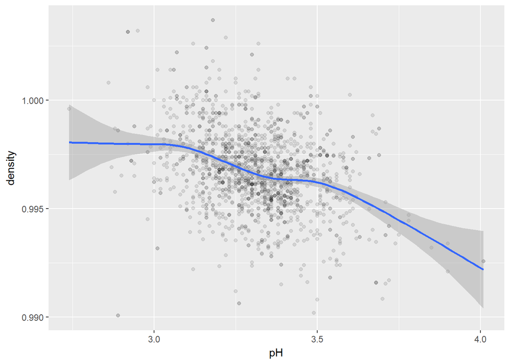

```
##
##  Pearson's product-moment correlation
##
## data:  wineframe$pH and wineframe$density
## t = -14.53, df = 1597, p-value < 2.2e-16
## alternative hypothesis: true correlation is not equal to 0
## 95 percent confidence interval:
##  -0.3842835 -0.2976642
## sample estimates:
##        cor
## -0.3416993
```

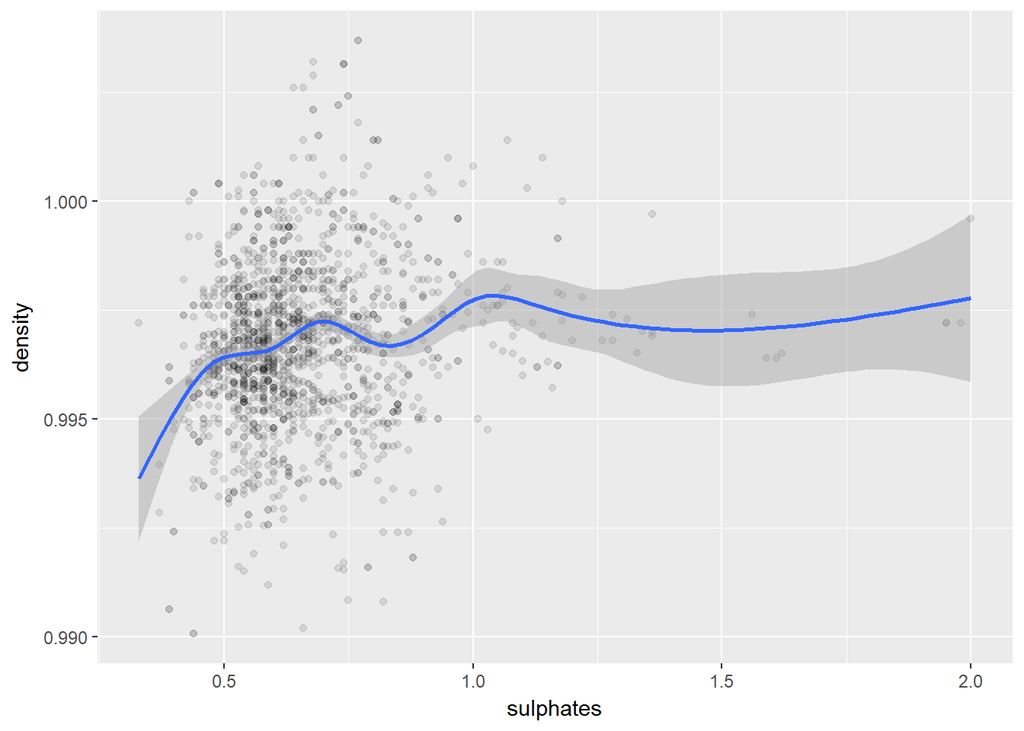

```
##
##  Pearson's product-moment correlation
##
## data:  wineframe$sulphates and wineframe$density
## t = 6.0012, df = 1597, p-value = 2.418e-09
## alternative hypothesis: true correlation is not equal to 0
## 95 percent confidence interval:
##  0.1002148 0.1961000
## sample estimates:
##       cor
## 0.1485064
```

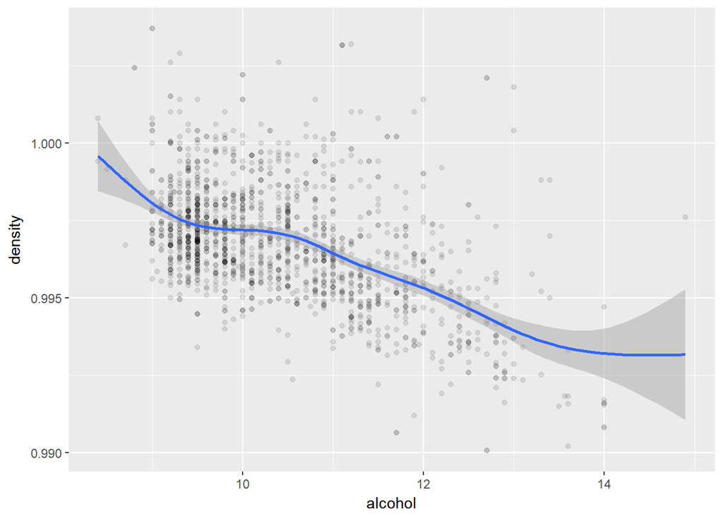

```
##
##  Pearson's product-moment correlation
##
## data:  wineframe$alcohol and wineframe$density
## t = -22.838, df = 1597, p-value < 2.2e-16
## alternative hypothesis: true correlation is not equal to 0
## 95 percent confidence interval:
##  -0.5322547 -0.4583061
## sample estimates:
##        cor
## -0.4961798
```

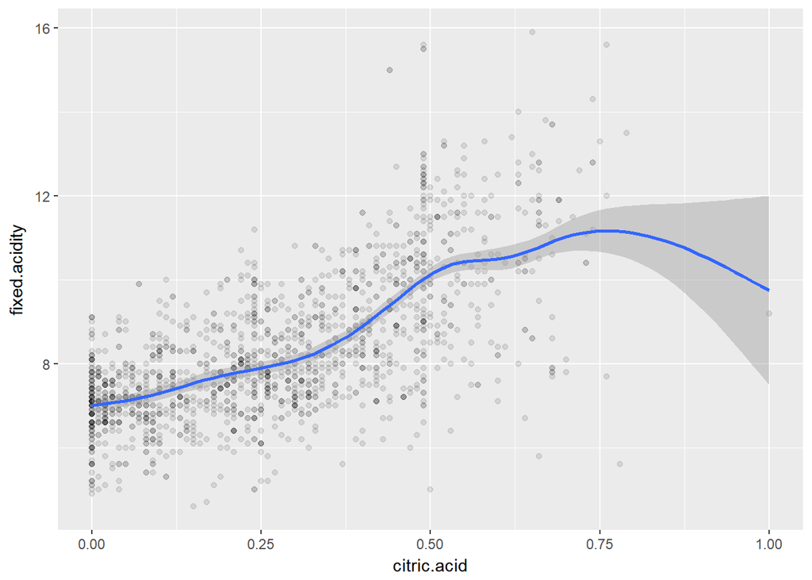

```
##
##  Pearson's product-moment correlation
##
## data:  wineframe$citric.acid and wineframe$fixed.acidity
## t = 36.234, df = 1597, p-value < 2.2e-16
## alternative hypothesis: true correlation is not equal to 0
## 95 percent confidence interval:
##  0.6438839 0.6977493
## sample estimates:
##       cor
## 0.6717034
```

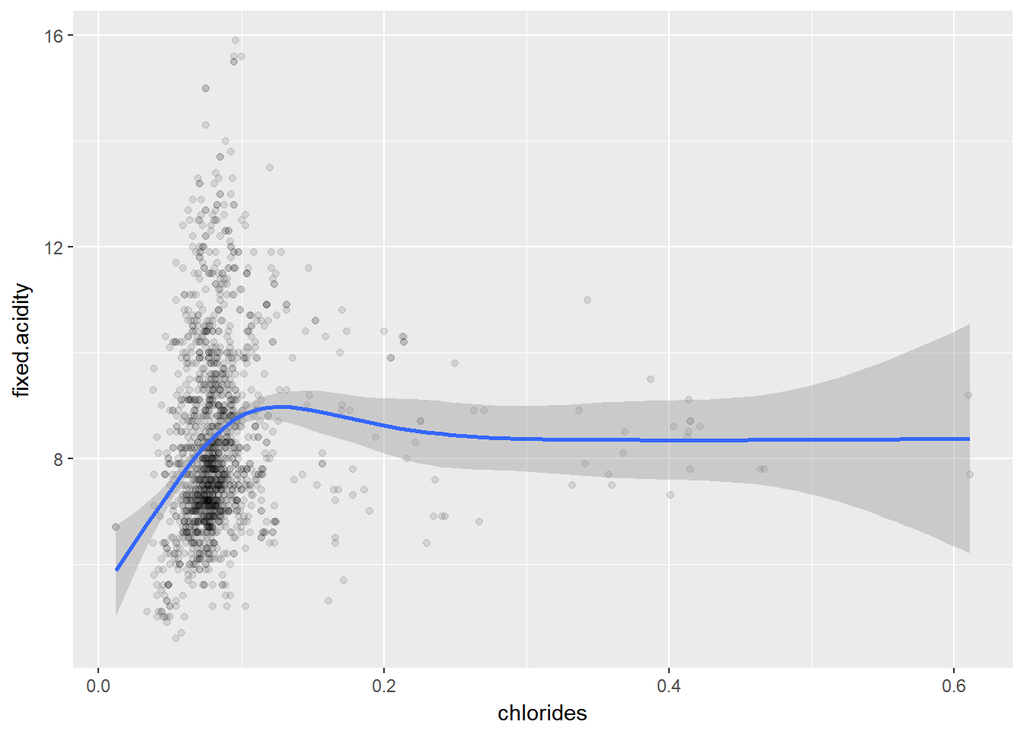

```
##
##  Pearson's product-moment correlation
##
## data:  wineframe$chlorides and wineframe$fixed.acidity
## t = 3.7612, df = 1597, p-value = 0.0001752
## alternative hypothesis: true correlation is not equal to 0
## 95 percent confidence interval:
##  0.04489025 0.14207371
## sample estimates:
##        cor
## 0.09370519
```

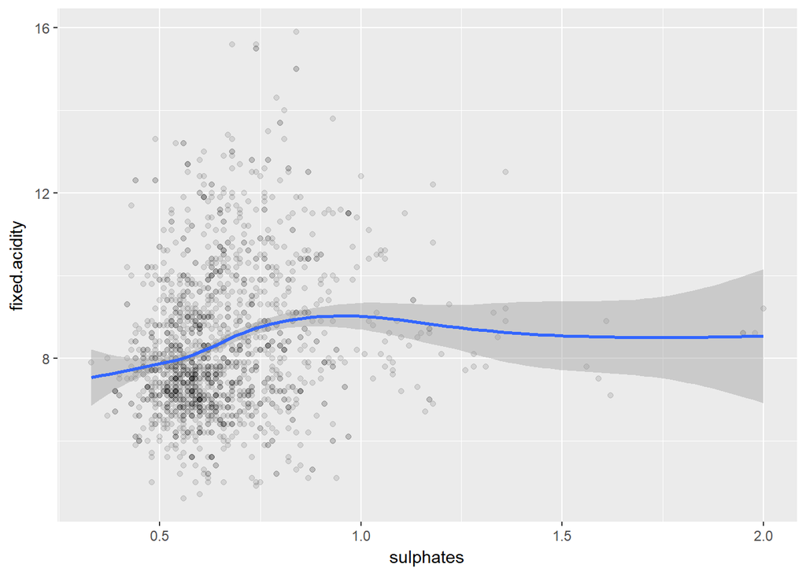

```
##
##  Pearson's product-moment correlation
##
## data:  wineframe$sulphates and wineframe$fixed.acidity
## t = 7.439, df = 1597, p-value = 1.649e-13
## alternative hypothesis: true correlation is not equal to 0
## 95 percent confidence interval:
##  0.1351974 0.2299638
## sample estimates:
##       cor
## 0.1830057
```

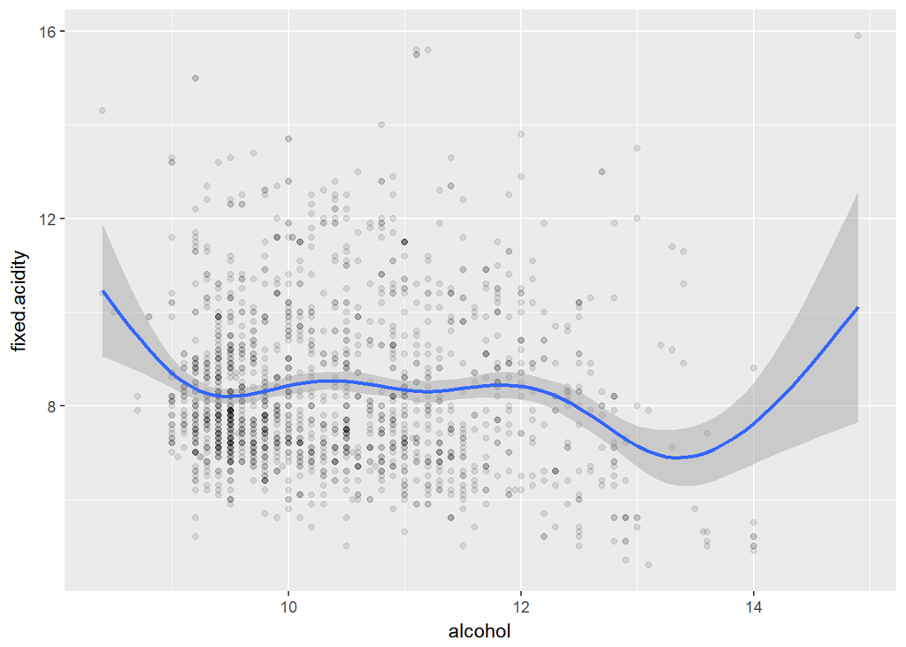

```
##
##  Pearson's product-moment correlation
##
## data:  wineframe$alcohol and wineframe$fixed.acidity
## t = -2.4691, df = 1597, p-value = 0.01365
## alternative hypothesis: true correlation is not equal to 0
## 95 percent confidence interval:
##  -0.11035580 -0.01268548
## sample estimates:
##         cor
## -0.06166827
```

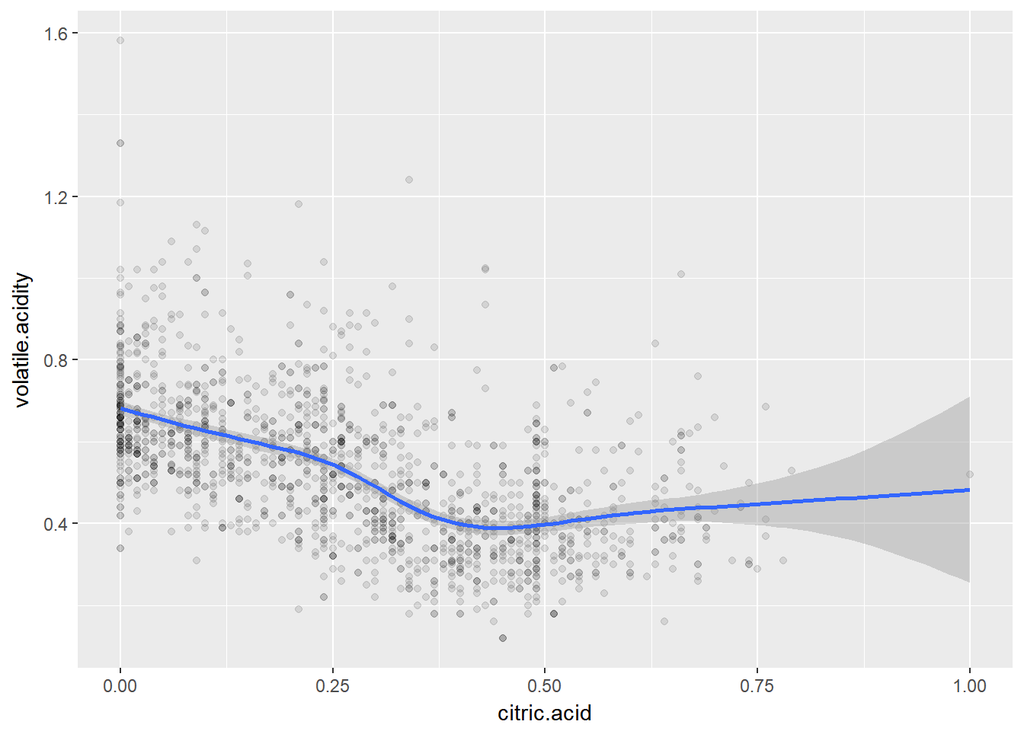

```
##
##  Pearson's product-moment correlation
##
## data:  wineframe$citric.acid and wineframe$volatile.acidity
## t = -26.489, df = 1597, p-value < 2.2e-16
## alternative hypothesis: true correlation is not equal to 0
## 95 percent confidence interval:
##  -0.5856550 -0.5174902
## sample estimates:
##        cor
## -0.5524957
```

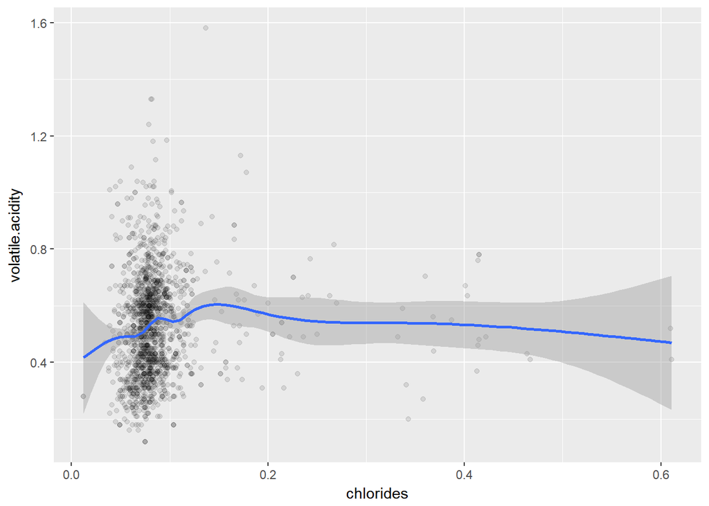

```
##
##  Pearson's product-moment correlation
##
## data:  wineframe$chlorides and wineframe$volatile.acidity
## t = 2.4542, df = 1597, p-value = 0.01422
## alternative hypothesis: true correlation is not equal to 0
## 95 percent confidence interval:
##  0.01231363 0.10998841
## sample estimates:
##        cor
## 0.06129777
```

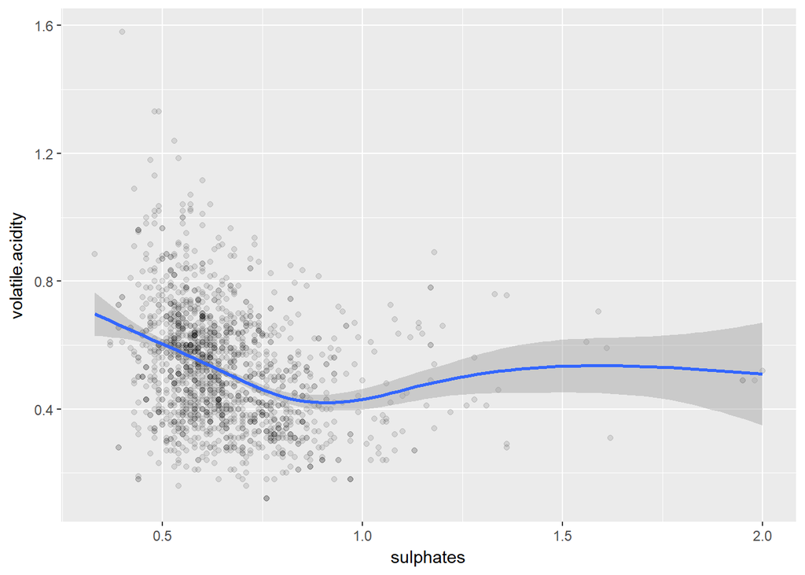

```
##
##  Pearson's product-moment correlation
##
## data:  wineframe$sulphates and wineframe$volatile.acidity
## t = -10.804, df = 1597, p-value < 2.2e-16
## alternative hypothesis: true correlation is not equal to 0
## 95 percent confidence interval:
##  -0.3060917 -0.2147125
## sample estimates:
##        cor
## -0.2609867
```

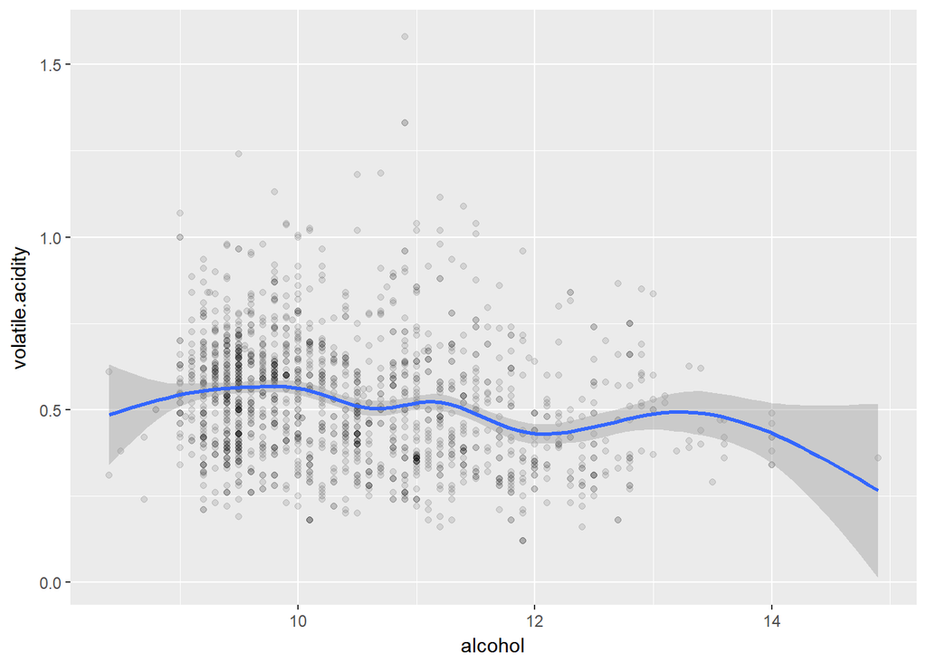

```
##
##  Pearson's product-moment correlation
##
## data:  wineframe$alcohol and wineframe$volatile.acidity
## t = -8.2546, df = 1597, p-value = 3.155e-16
## alternative hypothesis: true correlation is not equal to 0
## 95 percent confidence interval:
##  -0.2488416 -0.1548020
## sample estimates:
##       cor
## -0.202288
```

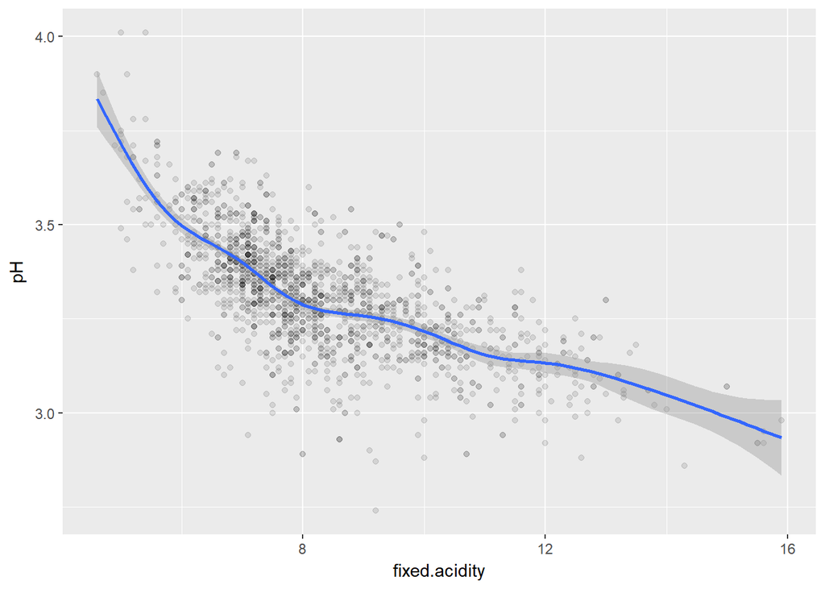

```
##
##  Pearson's product-moment correlation
##
## data:  wineframe$fixed.acidity and wineframe$pH
## t = -37.366, df = 1597, p-value < 2.2e-16
## alternative hypothesis: true correlation is not equal to 0
## 95 percent confidence interval:
##  -0.7082857 -0.6559174
## sample estimates:
##        cor
## -0.6829782
```

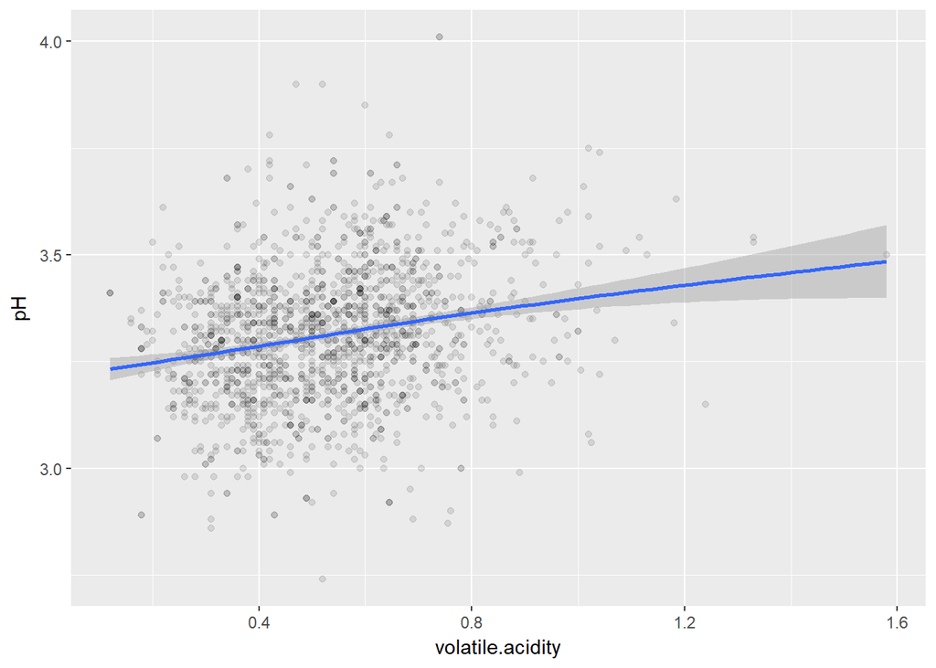

```
##
##  Pearson's product-moment correlation
##
## data:  wineframe$volatile.acidity and wineframe$pH
## t = 9.659, df = 1597, p-value < 2.2e-16
## alternative hypothesis: true correlation is not equal to 0
## 95 percent confidence interval:
##  0.1880823 0.2807254
## sample estimates:
##       cor
## 0.2349373
```

# Observation based on above statistics

# Bivariate Analysis

### Talk about some of the relationships you observed in this part of the investigation. How did the feature(s) of interest vary with other features in the dataset?

1. Alcohol, Citric acid, sulphates, chlorides are the main variables which influence the wine quality.
2. Residual sugar, free and total sufur dioxide does not influence the wine quality
3. citric acid, sulphates, alcohol seem to have positive correlation with the wine quality
4. chlorides Value seem to have negative correlation with the wine quality.

### Did you observe any interesting relationships between the other features (not the main feature(s) of interest)?

In general as the acidity increases, pH value will decrease but when we check the volatile acidity relationship with pH - there is positive correlation. It seems as volatile acidity increases, acidity of the solution is getting decreased (increase in pH Value).

Alcohol has medium negative correlation with density. Higher the alcohol content,lower the density becomes.

### What was the strongest relationship you found?

Fixed acidity has very strong correlation with the pH Value - value is -0.68

# Multivariate Plots Section

Here we will study about below relationships using scatter plot.

1. Alcohol vs Sulphates - for each quality level.
2. Citric acid vs chlorides - for each quality level.
3. Citric acid vs Density - for each quality level and alcohol content.

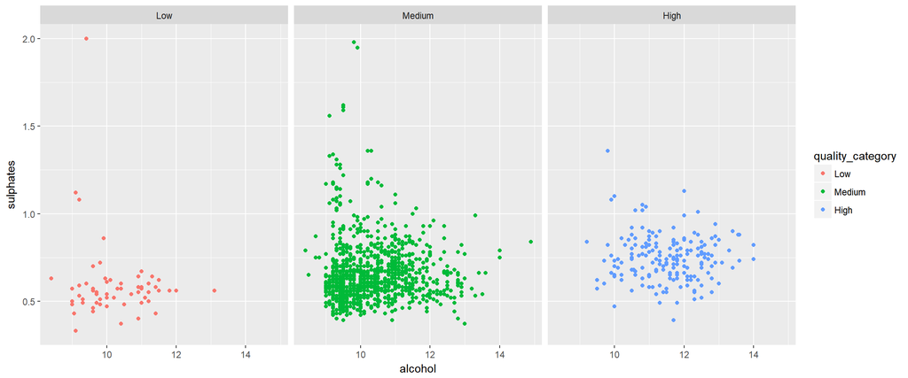

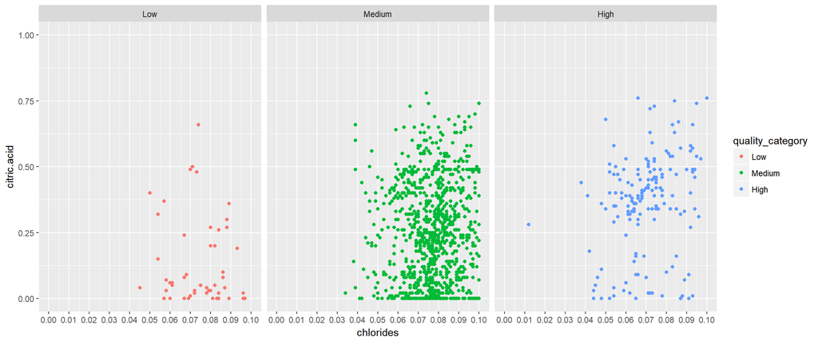

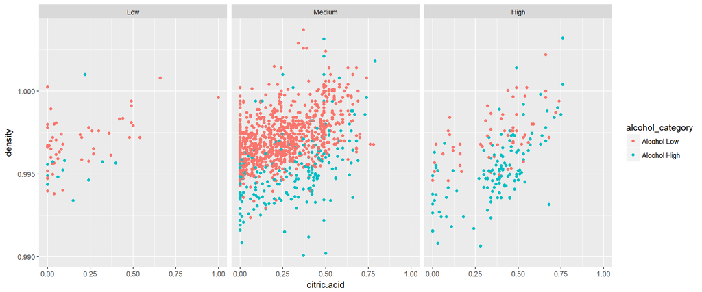

# Multivariate Analysis

### Were there any interesting or surprising interactions between features?

1. Scatter plot between citric acid and density based on the alcohol content, as well as quality of the wine had interesting scenario, where if citric acid increases density also increases- there is positive medium correlation.

Citric acid increases, quality of the wine also improves (Based on results from correlation) Density increases, quality of wine tends to decrease.

We can observe in the scatter plot, based on the alcohol content, density of the wine is getting reduced and so quality is getting improved. In the low quality wine plot, we can see high density, low citric acid and low alcohol content. In the medium quality plot, citric acid is good, but content of alcohol is influencing the density. In the high quality plot, citric acis is good, but content of alcohol is high and hence majority have low density.

# Final Plots and Summary

We will have three plots under this section

1. plot1 - To see how the amount of alcohol plays a crucial role in making a medium quality wine to a high quality.
2. plot2 - To see how alcohol and sulphates influence the wine quality.
3. plot3 - To depict the relationship between citric acid, density, alocohol and quality of the wine.

### Plot One

1. plot1 - To see how the amount of alcohol plays a crucial role in making a medium quality wine to a high quality

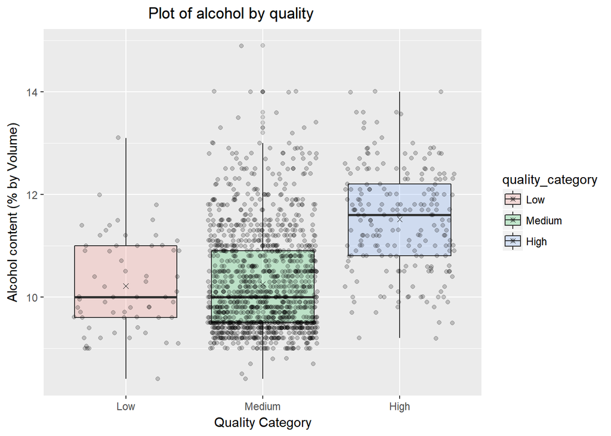

```
## wineframe$quality_category: Low
##    Min. 1st Qu.  Median    Mean 3rd Qu.    Max.
##    8.40    9.60   10.00   10.22   11.00   13.10
## --------------------------------------------------------
## wineframe$quality_category: Medium
##    Min. 1st Qu.  Median    Mean 3rd Qu.    Max.
##    8.40    9.50   10.00   10.25   10.90   14.90
## --------------------------------------------------------
## wineframe$quality_category: High
##    Min. 1st Qu.  Median    Mean 3rd Qu.    Max.
##    9.20   10.80   11.60   11.52   12.20   14.00
```

### Description One

An interesting observation in this plot is that, for both low and medium quality, the alcohol value seems to be the same. but when alcohol content increased to certain value , quality of the wine changes to high.

### Plot Two

plot2 - To see how alcohol and sulphate influence the wine quality.

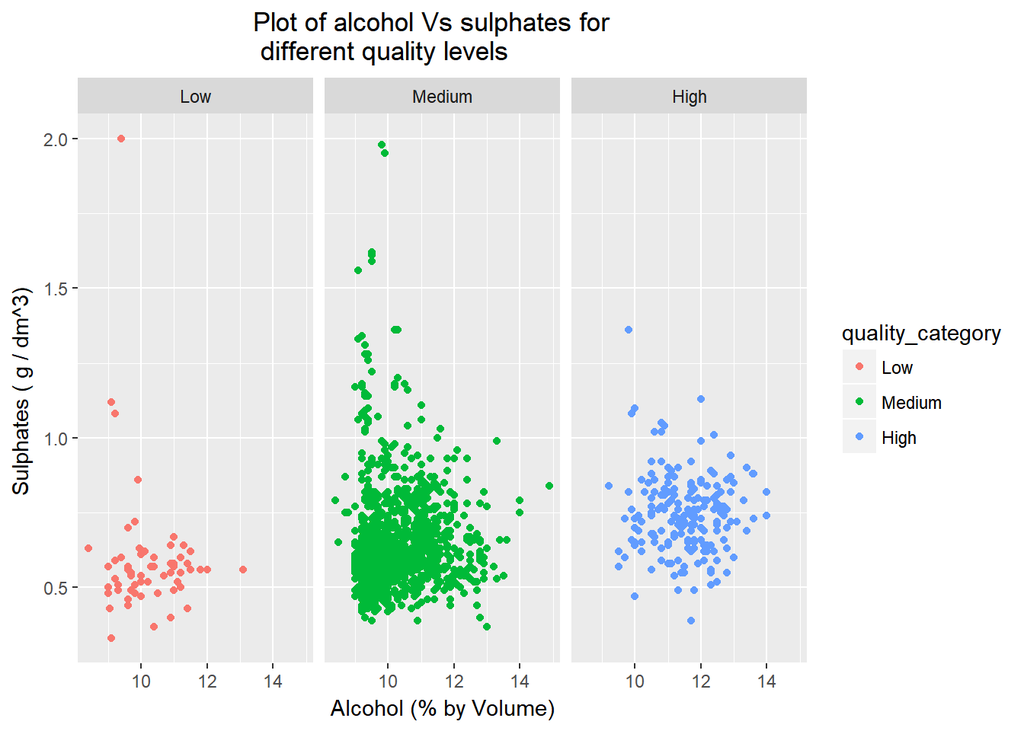

### Description Two

Basic inference from the above plot is that, as sulphates increases then the wine quality increases. Also increase in alcohol has resulted in the increase in the quality of the wine.

### Plot Three

This plot is to study the relationship between citric acid and Density for every quality of the wine and alcohol category.

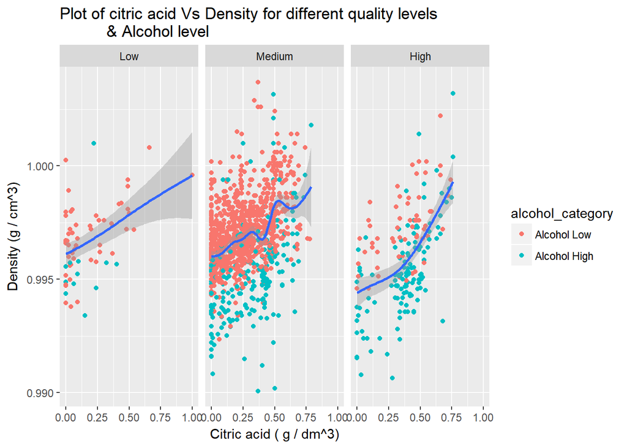

### Description Three

In this plot, we can observe that the following

1)Increase in citric acid, increases the density and quality of wine.

2)Increase in density is impacting the quality of the wine - high density wines have low quality.

3)Increase in alcohol, decreases the density and quality of wine increases

# Reflection

We started the analysis by studying the histogram plot for all the variables.

We observed few variables had normal distribtuion and few had positive skewed distribution.

Then we studied what are the variables that affect the wine quality by using the box plot. we also built a dataframe which contained for every quality level, what was the median value for all other variables. Based on that dataframe, we were trying to compute the correlation between the wine quality and other variables. Note : we took the median value to compare this statistic.

We came to conlusion that

Alcohol, citric acid, sulphates , chloride, Fixed acidity, volatile acidity, density, pH.

are the variables playing important role in the determining the wine quality.

Some of the challenges faced when analysing this dataset was that, more plots/statistics had to be performed to find out how the variables like fixed acidity, volatile acidity, pH , density are dependent on the other critical variables like citric acid , alcohol, sulphates etc .

By studying the correlation , we could conclude variables like fixed acidity, volatile acidity,pH can be replaced by single variable called Citric acid. In other words, percentage of citric acid determine the variables like fixed acidity, volatile acidity,pH.

We had to spend more time to conclude variables like sulfur dioxide and residual sugar do not contribute to the wine quality.

Thus I could successfully identify the critical variables that influence the wine quality.

Surprising information that was observed during the analysis was that volatile acidity refers to reduction in acidity value.

This dataset could have been more better - 1) if there has been more records for the low and high quality of wine. 2) Also dataset should have had records with wine quality values 0,1,2,9,10. 3) Also if for the same wine, there could have been multiple ratings provided by different judges would have also made the data little interesting. 4) could have added few more variables like wine Sweetness value etc to determine how those factors affect the wine quality.